# Analysis of Flight Delays

## by Andrea Claudia Villanca Rosales

## Investigation Overview

The goal of this investigation was to figure out which features are more related to a flight delay. The main focus was on the time-related factors like Month, Day of Month, Day of Week, Weekday/Weekend and Scheduled Arrival Hour.

The delay analysis in this project focus on arrival delays, specifically A+15 (arrival at the gate within 15 minutes after scheduled arrival), as that is the measure that the U.S. Department of Transportation (U.S.DOT) reports.

## Dataset Overview

The investigation explored the U.S.DOT dataset of 2007 flights in the United States. This dataset provides information about airline on-time performance and flight delays. It covers non stop scheduled-service flights between points within the United States (including territories) reported by 21 carriers.

There are 7,275,259 flights in the cleaned dataset with 13 features.

## Distribution of Delayed Flights

In our clean dataset, only 24.8% of flights were delayed. This was not a surprise because most airlines report time-related KPIs to the aviation authorities and airports in order to keep their operations.

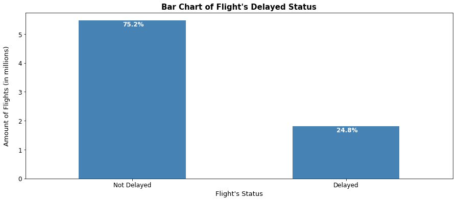

```python
# Let's plot the distribution of annual delayed flights
func_viz()
```

## Delayed Flights through the months

The amount of delayed flights is always lower than the amount of not delayed flights throughout the months. This pattern mostly remains even when analyzing it on a multivariate level by scheduled arrival hour, day of month, day of week or weekday/weekend.

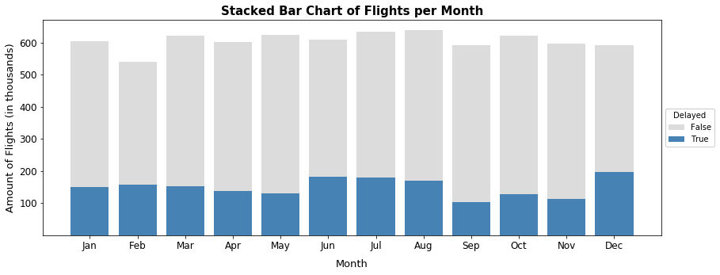

```python
# Let's plot the amount of delayed and not delayed flights per month
func_viz1()
```

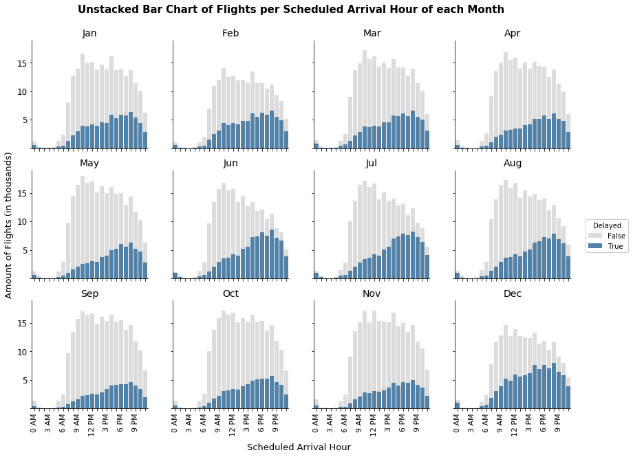

```python
# Let's plot the amount of delayed and not delayed flights per scheduled arrival hour of each month
func_viz2()
```

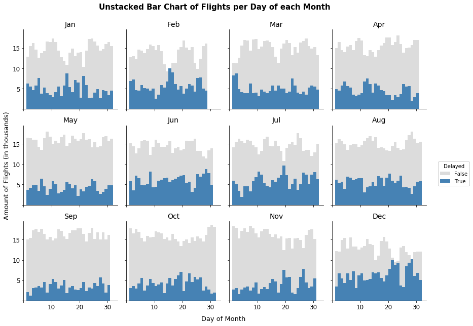

```python
# Let's plot the amount of delayed and not delayed flights each day of each month
func_viz3()
```

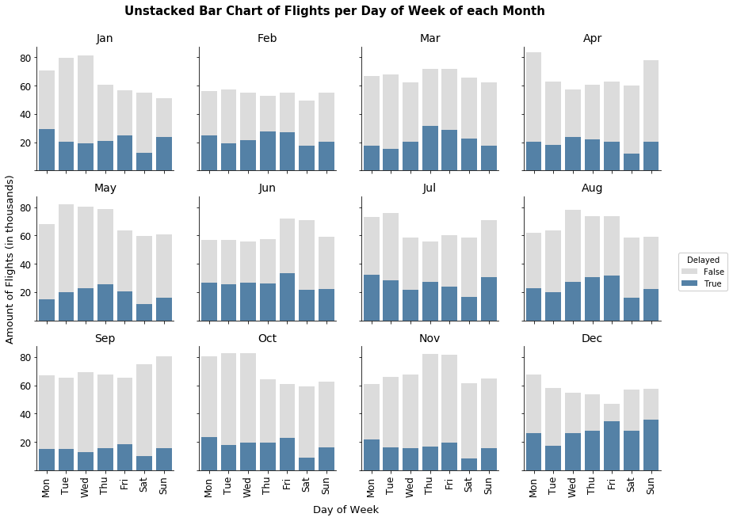

```python
# Let's plot the amount of delayed and not delayed flights each day of week of   each month
func_viz4()
```

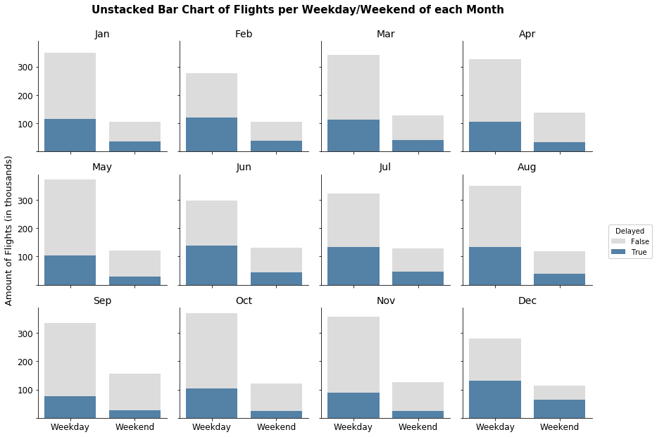

```python
# Let's plot the amount of delayed and not delayed flights each weekday/weekend  of each month
func_viz5()
```

## Percentage of Delayed Flights per hour

There is a spike in the percent of delays per hour between 9 PM and 0 AM (inclusive), and a notable reduction in the percent of delays at 7 AM. This annual pattern also remains on a multivariate level through most of the months.

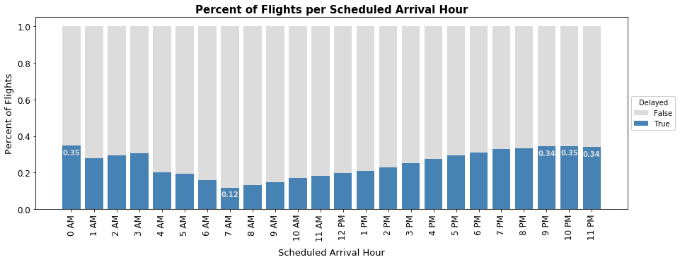

```python
# Let's plot the Annual Percent of Flights per Scheduled Arrival Hour
func_stack()
```

## Percentage of Delayed Flights per day of week

The percent of delayed flights per day of week hits its lowest on Saturday. This annual pattern also remains on a multivariate level through most of the months.

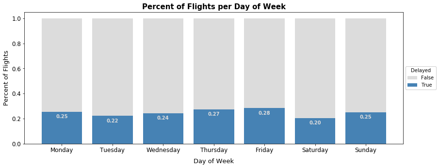

```python
# Let's plot the Annual Percent of Flights per Day of Week
func_bar()
```

## Percentage of Delayed Flights per weekday/weekend

The percent of delayed flights per is similar for both weekdays and weekends, however, the percentage of delayed flights is slightly higher on weekdays. This annual pattern also remains on a multivariate level through most of the months.

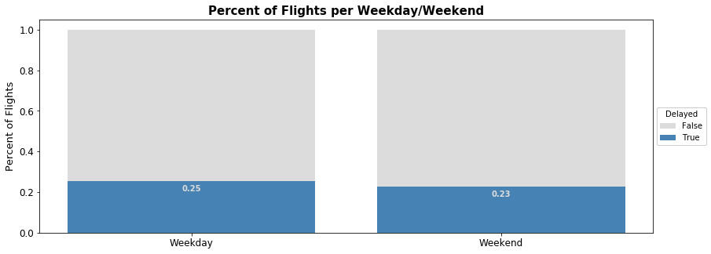

```python
# Let's plot the Annual Percent of Flights per Weekday/Weekend
func__bar()
```